# Lista 1 Sobrevivencia

Davi Wentrick Feijó - 200016806

2023-09-18

#### Exercıcio 1: Em um estudo com 15 pacientes submetidos a hemodialise, foram registrados os tempos decorridos desde a primeira dialise ate o obito (em meses). Todos os pacientes entraram juntos no inıcio do estudo e a informacao (em meses) de cada paciente e dada por:

$$6 \ \ 4 \ \ 12^+ \ \ 3^+ \ \ 1 \ \ 3 \ \ 1 \ \ 2 \ \ 3 \ \ 9^+ \ \ 10 \
\ 11 \ \ 5^+ \ \ 5 \ \ 1$$

##### a) Defina a resposta do estudo

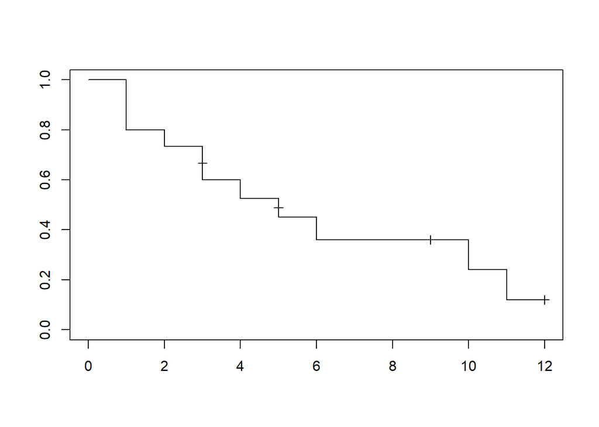

```r
tempo = c(6,4,12,3,1,3,1,2,3,9,10,11,5,5,1)
censura = c(1,1,0,0,1,1,1,1,1,0,1,1,0,1,1)

dados = data.frame(tempo,censura) %>%
  arrange(tempo)


#modelo de sobrevivencia

KM = survfit(Surv(dados$tempo,dados$censura)~1)

plot(KM,conf.int = F, mark.time = T)
```

```r
summary(KM)
```

```
## Call: survfit(formula = Surv(dados$tempo, dados$censura) ~ 1)
##
##  time n.risk n.event survival std.err lower 95% CI upper 95% CI
##     1     15       3    0.800   0.103       0.6212        1.000
##     2     12       1    0.733   0.114       0.5405        0.995
##     3     11       2    0.600   0.126       0.3969        0.907
##     4      8       1    0.525   0.131       0.3219        0.856
##     5      7       1    0.450   0.132       0.2532        0.800
##     6      5       1    0.360   0.133       0.1747        0.742
##    10      3       1    0.240   0.132       0.0816        0.706
##    11      2       1    0.120   0.108       0.0207        0.695
```

##### b) identifique o tipo de censura observado nesse estudo

Censura a direita, pois elas ocorreram depois do inicio do estudo.

#### Exercıcio 2: Um numero grande de indivıduos foi acompanhado para estudar o aparecimento de um certo sintoma. Os indivıduos foram incluıdos ao longo do estudo e foi considerada como resposta de interesse a idade em que este sintoma apareceu pela primeira vez. Para os seis indivıduos selecionados e descritos a seguir, identifique o tipo de censura apresentado.

##### a) O primeiro indivıduo entrou no estudo com 25 anos ja apresentando o sintoma.

Censura a esquerda pois o evento ocorreu antes do inicio do estudo

##### b) Outros dois indivıduos entraram no estudo com 20 e 28 anos e nao apresentaram o sintoma até o encerramento do estudo

Censura a direita pois o evento nao ocorreu no tempo de estudo

##### c) Outros dois indivıduos entraram com 35 e 40 anos e apresentaram o sintoma no segundo e no sexto exames, respectivamente, apos terem entrado no estudo. Os exames foram realizados a cada dois anos.

Censura intervalar pois o envento ocorreu no intervalo de tempo entre os exames

##### d) O ultimo indivıduo selecionado entrou no estudo com 36 anos e mudou da cidade depois de 4 anos sem ter apresentado o sintoma.

Censura a direita pois nao teve a ocorencia do efeito de interesse

#### Exercicio 3: Mostre que:

##### b) $H(t) = \int_{0}^{t}h(u)du = - log(S(t))$

#### Exercıcio 4: Seja T uma variavel aleatoria com distribuicao Pareto com parametros $\alpha > 0$ e $\beta > 0$. A funcao de risco de T e dada por:

$$h(t) = \frac{\alpha}{\beta + t}, \ \ t> 0$$

Determine as funcoes $S(t)$ e $f(t)$ da distribuicao Pareto.